# Project: Investigate a Dataset (No Show Appointments)

- Introduction
- Data Wrangling
- Exploratory Data Analysis
- Conclusions

## Introduction

the data set selected contains patients showed and unshowed in their medical appointments, and we need to analyze the reasons and variables that make them not showing up at their medical appointments

### Questions

1) Does WaitingDuration has a big influence on non showing up for appointments?

2) Does Age has a big influence on non showing up for appointments?

3) Does SMS has a big influence on non showing up for appointments?

4) Does a certain gender influence whether one shows up to appointments?

5) Does Scholarship influence whether one shows up to appointments?

6) Does Hipertension influence whether one shows up to appointments?

7) Does Diabetes influence whether one shows up to appointments?

8) Does Alcoholism influence whether one shows up to appointments?

9) Does Handcap influence whether one shows up to appointments?

```python
import pandas as pd
import matplotlib.pyplot as plt
import seaborn as sns
%matplotlib inline
```

## Data Wrangling

```python
df = pd.read_csv('Database_No_show_appointments/noshowappointments-kagglev2-may-2016.csv')
df.sample(3)
```

|  | PatientId | AppointmentID | Gender | ScheduledDay | AppointmentDay | Age | Neighbourhood | Scholarship | Hipertension | Diabetes | Alcoholism | Handcap | SMS_received | No-show |
| --- | --- | --- | --- | --- | --- | --- | --- | --- | --- | --- | --- | --- | --- | --- |
| 46316 | 1.225782e+11 | 5705858 | F | 2016-05-17T07:34:27Z | 2016-05-17T00:00:00Z | 34 | DA PENHA | 1 | 0 | 0 | 0 | 0 | 0 | No |
| 39475 | 7.876899e+13 | 5676720 | M | 2016-05-09T16:19:34Z | 2016-05-11T00:00:00Z | 33 | DO QUADRO | 0 | 0 | 0 | 0 | 0 | 0 | No |
| 10031 | 4.238992e+12 | 5715649 | M | 2016-05-18T14:48:33Z | 2016-05-18T00:00:00Z | 44 | ROMÃO | 0 | 0 | 0 | 0 | 0 | 0 | No |

```python
df.info()
```

```
<class 'pandas.core.frame.DataFrame'>
RangeIndex: 110527 entries, 0 to 110526
Data columns (total 14 columns):
PatientId         110527 non-null float64
AppointmentID     110527 non-null int64
Gender            110527 non-null object
ScheduledDay      110527 non-null object
AppointmentDay    110527 non-null object
Age               110527 non-null int64
Neighbourhood     110527 non-null object
Scholarship       110527 non-null int64
Hipertension      110527 non-null int64
Diabetes          110527 non-null int64
Alcoholism        110527 non-null int64
Handcap           110527 non-null int64
SMS_received      110527 non-null int64
No-show           110527 non-null object
dtypes: float64(1), int64(8), object(5)
memory usage: 11.8+ MB
```

checking the info of the dataframe, we found that there are 110527 rows and 14 columns with no null values

```python
df.describe()
```

|  | PatientId | AppointmentID | Age | Scholarship | Hipertension | Diabetes | Alcoholism | Handcap | SMS_received |
| --- | --- | --- | --- | --- | --- | --- | --- | --- | --- |
| count | 1.105270e+05 | 1.105270e+05 | 110527.000000 | 110527.000000 | 110527.000000 | 110527.000000 | 110527.000000 | 110527.000000 | 110527.000000 |
| mean | 1.474963e+14 | 5.675305e+06 | 37.088874 | 0.098266 | 0.197246 | 0.071865 | 0.030400 | 0.022248 | 0.321026 |
| std | 2.560949e+14 | 7.129575e+04 | 23.110205 | 0.297675 | 0.397921 | 0.258265 | 0.171686 | 0.161543 | 0.466873 |
| min | 3.921784e+04 | 5.030230e+06 | -1.000000 | 0.000000 | 0.000000 | 0.000000 | 0.000000 | 0.000000 | 0.000000 |
| 25% | 4.172614e+12 | 5.640286e+06 | 18.000000 | 0.000000 | 0.000000 | 0.000000 | 0.000000 | 0.000000 | 0.000000 |
| 50% | 3.173184e+13 | 5.680573e+06 | 37.000000 | 0.000000 | 0.000000 | 0.000000 | 0.000000 | 0.000000 | 0.000000 |
| 75% | 9.439172e+13 | 5.725524e+06 | 55.000000 | 0.000000 | 0.000000 | 0.000000 | 0.000000 | 0.000000 | 1.000000 |
| max | 9.999816e+14 | 5.790484e+06 | 115.000000 | 1.000000 | 1.000000 | 1.000000 | 1.000000 | 4.000000 | 1.000000 |

from the dataframe description we found that the min age is negative, therefore we need to check it

```python
df.isnull().sum()
```

```
PatientId         0
AppointmentID     0
Gender            0
ScheduledDay      0
AppointmentDay    0
Age               0
Neighbourhood     0
Scholarship       0
Hipertension      0
Diabetes          0
Alcoholism        0
Handcap           0
SMS_received      0
No-show           0
dtype: int64
```

no null values in the dataframe

```python
df.duplicated().sum()
```

```
0
```

no duplicated rows in the dataframe

```python
df.Age.max(), df.Age.min()
```

```
(115, -1)
```

min age is -1, we need to clean it

### Data Cleaning

we need to get the index of the row containing min age value of -1

```python
df.query('Age == "-1"').index[0]
```

```
99832
```

```python
df.shape
```

```
(110527, 14)
```

we have to drop the row that contain age value of -1 to clean our data

```python
df.drop(df.index[99832], inplace=True)
```

```python
df.shape
```

```
(110526, 14)
```

```python
df.info()
```

```
<class 'pandas.core.frame.DataFrame'>
Int64Index: 110526 entries, 0 to 110526
Data columns (total 14 columns):
PatientId         110526 non-null float64
AppointmentID     110526 non-null int64
Gender            110526 non-null object
ScheduledDay      110526 non-null object
AppointmentDay    110526 non-null object
Age               110526 non-null int64
Neighbourhood     110526 non-null object
Scholarship       110526 non-null int64
Hipertension      110526 non-null int64
Diabetes          110526 non-null int64
Alcoholism        110526 non-null int64
Handcap           110526 non-null int64
SMS_received      110526 non-null int64
No-show           110526 non-null object
dtypes: float64(1), int64(8), object(5)
memory usage: 12.6+ MB
```

```python
df.sample()
```

|  | PatientId | AppointmentID | Gender | ScheduledDay | AppointmentDay | Age | Neighbourhood | Scholarship | Hipertension | Diabetes | Alcoholism | Handcap | SMS_received | No-show |
| --- | --- | --- | --- | --- | --- | --- | --- | --- | --- | --- | --- | --- | --- | --- |
| 37665 | 1.275834e+12 | 5646821 | F | 2016-05-02T11:53:54Z | 2016-05-09T00:00:00Z | 17 | JESUS DE NAZARETH | 0 | 0 | 0 | 0 | 0 | 0 | Yes |

we will change the AppointmentDay and ScheduledDay to datetime type

```python
df['AppointmentDate'] = pd.to_datetime(df.AppointmentDay).dt.date
df.drop('AppointmentDay',axis=1, inplace = True)
df['ScheduledDate'] = pd.to_datetime(df.ScheduledDay).dt.date
df.drop('ScheduledDay',axis=1, inplace = True)
```

```python
df.sample()
```

|  | PatientId | AppointmentID | Gender | Age | Neighbourhood | Scholarship | Hipertension | Diabetes | Alcoholism | Handcap | SMS_received | No-show | AppointmentDate | ScheduledDate |
| --- | --- | --- | --- | --- | --- | --- | --- | --- | --- | --- | --- | --- | --- | --- |
| 11460 | 3.115364e+13 | 5589137 | F | 68 | MONTE BELO | 0 | 0 | 0 | 0 | 0 | 0 | No | 2016-05-18 | 2016-04-15 |

we will add a column for WaitingDuration that contains the difference between AppointmentDate and ScheduledDate to check if that waiting time affects the No-show for the medical appointments

```python
df['WaitingDuration'] = df.AppointmentDate - df.ScheduledDate
df[df.WaitingDuration < '0 days']
df.WaitingDuration = (df.AppointmentDate - df.ScheduledDate).astype('timedelta64[D]').astype(int)
```

```python
df.sample(5)
```

|  | PatientId | AppointmentID | Gender | Age | Neighbourhood | Scholarship | Hipertension | Diabetes | Alcoholism | Handcap | SMS_received | No-show | AppointmentDate | ScheduledDate | WaitingDuration |
| --- | --- | --- | --- | --- | --- | --- | --- | --- | --- | --- | --- | --- | --- | --- | --- |
| 33869 | 2.234337e+13 | 5698154 | F | 69 | GURIGICA | 0 | 0 | 0 | 0 | 0 | 0 | No | 2016-05-16 | 2016-05-16 | 0 |
| 90422 | 2.577500e+12 | 5755388 | F | 48 | FONTE GRANDE | 0 | 0 | 0 | 0 | 0 | 0 | No | 2016-06-01 | 2016-06-01 | 0 |
| 46030 | 4.277763e+12 | 5721921 | M | 22 | SÃO CRISTÓVÃO | 0 | 0 | 0 | 0 | 0 | 0 | No | 2016-05-19 | 2016-05-19 | 0 |
| 60422 | 4.928892e+12 | 5707685 | F | 63 | JABOUR | 0 | 0 | 0 | 0 | 0 | 0 | No | 2016-05-17 | 2016-05-17 | 0 |
| 40005 | 3.299985e+14 | 5707352 | F | 57 | CONQUISTA | 0 | 1 | 0 | 0 | 0 | 0 | No | 2016-05-17 | 2016-05-17 | 0 |

```python
df.shape
```

```
(110526, 15)
```

we will clear the datafram to contain only have AppointmentDate larger or equal than ScheduledDate, because it is non logical to have a negative WaitingDuration

```python
df = df[df.AppointmentDate >= df.ScheduledDate]
```

```python
df.shape
```

```
(110521, 15)
```

Adding dummy for no show so that we can use heatmap to get out the variables that have directly related correlation with non showing in the appointments

```python
dummy = pd.get_dummies(df['No-show'])
df = pd.concat([df, dummy], axis=1)
df.sample(3)
```

|  | PatientId | AppointmentID | Gender | Age | Neighbourhood | Scholarship | Hipertension | Diabetes | Alcoholism | Handcap | SMS_received | No-show | AppointmentDate | ScheduledDate | WaitingDuration | No | Yes |
| --- | --- | --- | --- | --- | --- | --- | --- | --- | --- | --- | --- | --- | --- | --- | --- | --- | --- |
| 7527 | 2.775442e+13 | 5616688 | M | 16 | BELA VISTA | 1 | 0 | 0 | 0 | 1 | 0 | No | 2016-05-11 | 2016-04-25 | 16 | 1 | 0 |
| 68847 | 1.578132e+12 | 5639322 | F | 64 | TABUAZEIRO | 1 | 1 | 1 | 0 | 0 | 0 | Yes | 2016-05-06 | 2016-04-29 | 7 | 0 | 1 |
| 21887 | 5.528716e+11 | 5624733 | F | 59 | BELA VISTA | 0 | 1 | 0 | 0 | 0 | 1 | No | 2016-05-06 | 2016-04-26 | 10 | 1 | 0 |

we will drop PatientId and AppointmentID columns

```python
df.drop('PatientId',axis='columns', inplace=True)
df.drop('AppointmentID',axis='columns', inplace=True)
```

```python
df.sample()
```

|  | Gender | Age | Neighbourhood | Scholarship | Hipertension | Diabetes | Alcoholism | Handcap | SMS_received | No-show | AppointmentDate | ScheduledDate | WaitingDuration | No | Yes |
| --- | --- | --- | --- | --- | --- | --- | --- | --- | --- | --- | --- | --- | --- | --- | --- |
| 110349 | M | 53 | RESISTÊNCIA | 0 | 0 | 0 | 0 | 0 | 0 | Yes | 2016-06-02 | 2016-05-31 | 2 | 0 | 1 |

we will check the correlation between the variables

```python
df.corr()
```

|  | Age | Scholarship | Hipertension | Diabetes | Alcoholism | Handcap | SMS_received | WaitingDuration | No | Yes |
| --- | --- | --- | --- | --- | --- | --- | --- | --- | --- | --- |
| Age | 1.000000 | -0.092469 | 0.504599 | 0.292398 | 0.095811 | 0.078101 | 0.012629 | 0.034813 | 0.060320 | -0.060320 |
| Scholarship | -0.092469 | 1.000000 | -0.019738 | -0.024899 | 0.035019 | -0.008555 | 0.001182 | -0.030435 | -0.029166 | 0.029166 |
| Hipertension | 0.504599 | -0.019738 | 1.000000 | 0.433082 | 0.087967 | 0.080162 | -0.006285 | -0.017236 | 0.035662 | -0.035662 |
| Diabetes | 0.292398 | -0.024899 | 0.433082 | 1.000000 | 0.018471 | 0.057578 | -0.014561 | -0.027200 | 0.015158 | -0.015158 |
| Alcoholism | 0.095811 | 0.035019 | 0.087967 | 0.018471 | 1.000000 | 0.004668 | -0.026154 | -0.038527 | 0.000181 | -0.000181 |
| Handcap | 0.078101 | -0.008555 | 0.080162 | 0.057578 | 0.004668 | 1.000000 | -0.024097 | -0.019774 | 0.006290 | -0.006290 |
| SMS_received | 0.012629 | 0.001182 | -0.006285 | -0.014561 | -0.026154 | -0.024097 | 1.000000 | 0.398128 | -0.126502 | 0.126502 |
| WaitingDuration | 0.034813 | -0.030435 | -0.017236 | -0.027200 | -0.038527 | -0.019774 | 0.398128 | 1.000000 | -0.186320 | 0.186320 |
| No | 0.060320 | -0.029166 | 0.035662 | 0.015158 | 0.000181 | 0.006290 | -0.126502 | -0.186320 | 1.000000 | -1.000000 |
| Yes | -0.060320 | 0.029166 | -0.035662 | -0.015158 | -0.000181 | -0.006290 | 0.126502 | 0.186320 | -1.000000 | 1.000000 |

therefore primary considerations should be waiting duration,age and sms recieved

## Exploratory Data Analysis

### Research Question 1: Does WaitingDuration has a big influence on non showing up for appointments?

```python
df.groupby(["No-show", "WaitingDuration"]).size()
```

```
No-show  WaitingDuration
No       0                  36770
         1                   4100
         2                   5123
         3                   2093
         4                   4059
         5                   2405
         6                   3036
         7                   3597
         8                   1662
         9                   1165
         10                   951
         11                   675
         12                   762
         13                  1146
```

[output cut: 48 more lines]

```python
df.groupby(["No", "WaitingDuration"]).size().head()
```

```
No  WaitingDuration
0   0                  1792
    1                  1113
    2                  1602
    3                   644
    4                  1231
dtype: int64
```

```python
df_new = df[df.No == 0]
```

[figure not shown]

```python
ax = df_new.WaitingDuration.plot(kind='hist')
plt.xlabel('WaitingDuration', fontsize= 16)
plt.ylabel('Number of Patients', fontsize=16)
plt.title('WaitingDuration vs no. of patients attended', fontsize=22)
plt.show()
```

### Research Question 2: Does Age has a big influence on non showing up for appointments?

```python
df.groupby(["No-show", "Age"]).size().head()
```

```
No-show  Age
No       0      2900
         1      1858
         2      1366
         3      1236
         4      1017
dtype: int64
```

```python
df_new1 = df[df.No == 1]
```

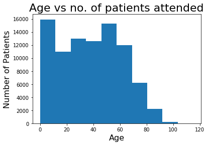

```python
ax = df_new1.Age.plot(kind='hist')
plt.xlabel('Age', fontsize= 16)
plt.ylabel('Number of Patients', fontsize=16)
plt.title('Age vs no. of patients attended', fontsize=22)
plt.show()
```

### Research Question 3: Does SMS has a big influence on non showing up for appointments?

```python
df.shape
```

```
(110521, 15)
```

```python
df.groupby(["No-show", "SMS_received"]).size()
```

```
No-show  SMS_received
No       0               62509
         1               25698
Yes      0               12530
         1                9784
dtype: int64
```

```python
def my_pie_chart(labels,cut_points,colors,title):
    fig1, ax = plt.subplots()
    ax.pie(cut_points, labels=labels, colors=colors, autopct='%1.1f%%')
    plt.title(title, fontsize= 20)
    ax.axis('equal')
    plt.show()
```

[figure not shown]

```python
labels = 'No SMS_received, No-show', 'No SMS_received, Showed', 'SMS_received, No-show', 'SMS_received, Show'
cut_points = [62509, 12530, 25698, 9784 ]
colors = ['red', 'yellow', 'blue', 'green']
title = 'No-show vs SMS_received'
my_pie_chart(labels,cut_points,colors,title)
```

Therefore recieving SMS didn't encourage patients to show up for thier medical appointments

### Research Question 4: Does a certain gender influence whether one shows up to appointments?

```python
df.groupby(['No-show','Gender']).size()
```

```
No-show  Gender
No       F         57245
         M         30962
Yes      F         14591
         M          7723
dtype: int64
```

[figure not shown]

```python
labels = 'Female, No-show', 'Female, Showed', 'Male, No-show', 'Male, Show'
cut_points = [57245, 14594, 30962, 7725 ]
colors = ['red', 'yellow', 'blue', 'green']
title = 'Proportion of Female and Male Patients'
my_pie_chart(labels,cut_points,colors,title)
```

### Research Question 5: Does Scholarship influence whether one shows up to appointments?

```python
df.groupby(["No-show", "Scholarship"]).size()
```

```
No-show  Scholarship
No       0              79924
         1               8283
Yes      0              19736
         1               2578
dtype: int64
```

[figure not shown]

```python
labels = 'No Scholarship, No-show', 'No Scholarship, Showed', 'Scholarship, No-show', 'Scholarship, Show'
cut_points = [79924, 19736, 8283, 2578 ]
colors = ['red', 'yellow', 'blue', 'green']
title = 'No-show vs Scholarship'
my_pie_chart(labels,cut_points,colors,title)
```

it is clear that the percentage of patients that don't have Scholarship is greater than the sum of the rest percentages

### Research Question 6: Does Hipertension influence whether one shows up to appointments?

```python
df.groupby(["No-show", "Hipertension"]).size()
```

```
No-show  Hipertension
No       0               70178
         1               18029
Yes      0               18542
         1                3772
dtype: int64
```

[figure not shown]

```python
labels = 'No Hipertension, No-show', 'No Hipertension, Showed', 'Hipertension, No-show', 'Hipertension, Show'
cut_points = [70178, 18542, 18029, 3772 ]
colors = ['red', 'yellow', 'blue', 'green']
title = 'No-show vs Hipertension'
my_pie_chart(labels,cut_points,colors,title)
```

it is clear that the percentage of patients that don't have Hipertension is greater than the sum of the rest percentages

Therefore, patients not having Hipertension tends to not show up for thier medical appointments

### Research Question 7: Does Diabetes influence whether one shows up to appointments?

```python
df.groupby(["No-show", "Diabetes"]).size()
```

```
No-show  Diabetes
No       0           81694
         1            6513
Yes      0           20884
         1            1430
dtype: int64
```

[figure not shown]

```python
labels = 'No Diabetes, No-show', 'No Diabetes, Showed', 'Diabetes, No-show', 'Diabetes, Show'
cut_points = [81694, 20884, 6513, 1430 ]
colors = ['red', 'yellow', 'blue', 'green']
title = 'No-show vs Diabetes'
my_pie_chart(labels,cut_points,colors,title)
```

it is clear that the percentage of patients that don't have Diabetes is greater than the sum of the rest percentages

Therefore, patients not having Diabetes tends to not show up for thier medical appointments

### Research Question 8: Does Alcoholism influence whether one shows up to appointments?

```python
df.groupby(["No-show", "Alcoholism"]).size()
```

```
No-show  Alcoholism
No       0             85524
         1              2683
Yes      0             21637
         1               677
dtype: int64
```

[figure not shown]

```python
labels = 'No Alcoholism, No-show', 'No Alcoholism, Showed', 'Alcoholism, No-show', 'Alcoholism, Show'
cut_points = [85524, 21637, 2683, 677 ]
colors = ['red', 'yellow', 'blue', 'green']
title = 'No-show vs Alcoholism'
my_pie_chart(labels,cut_points,colors,title)
```

it is clear that the percentage of patients that don't have Alcoholism is greater than the sum of the rest percentages

### Research Question 9: Does Handcap influence whether one shows up to appointments?

```python
df.groupby(["No-show", "Handcap"]).size()
```

```
No-show  Handcap
No       0          86373
         1           1676
         2            146
         3             10
         4              2
Yes      0          21909
         1            364
         2             37
         3              3
         4              1
dtype: int64
```

because all handcap types have very small values so it is better to use bar chart rather than pie chart for better visualization

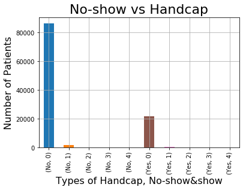

```python
ax = df.groupby(["No-show", "Handcap"]).size().plot(kind='bar',grid=True)
plt.xlabel('Types of Handcap, No-show&show', fontsize= 16)
plt.ylabel('Number of Patients', fontsize=16)
plt.title('No-show vs Handcap', fontsize=22)
plt.show()
```

it is clear that the percentage of patients that don't need special need is greater than the sum of the rest percentages

Therefore, patients not needing special needs tends to not show up for thier medical appointments

## Conclusions

_recieving SMS didn't encourage patients to show up for thier medical appointments

_patients not having Hipertension tends to not show up for thier medical appointments

_patients not having Diabetes tends to not show up for thier medical appointments

_patients not needing special needs tends to not show up for thier medical appointments

### Limitations

_Most of the visualization part is limited to pie chart due to the plenty of categorical data type columns

_Statistical testing and more detailed data segmentations would give us much more better results.

_data is from 2016, therefore need to be updated

_getting data for patients around the world would give us much more accurate results than only limiting data to brazil patients

```python
from subprocess import call
call(['python', '-m', 'nbconvert', 'Investigate_a_Dataset.ipynb'])
```

```
255
```